# Changing Nature of Death in Infancy in the United States

Kevin Dysart

12/8/2019

## Overview

Using the linked birth and death certificate data collected by the CDC the project aims to evaluate the changing nature of death amongst infants born less than 32 weeks gestation or 1,500g. Increasing use of clinical tools and therapeutic interventions, combined with a perceived shift in parent and clinician attitudes regarding the aggresive pursuit of life in this cohort, may be leading to an increasing time before death over the last 20 years.

## Introduction

Infants born less than 32 weeks or 1,500g of completed gestation continue to experience high mortality rates. Amongst infants in this category, those of the lowest gestational ages have the highest risk of mortality. Over the last 20 years, the presence of neonatal intensive care units have made intensive care therapies more available to an increasing number of infants. This availability, in combination with more aggressive support for infants at the youngest gestational ages, is leading to a small increase in survival over time. To this point in neonatal medicine, deaths typically occur early in the lives of infants in this cohort as a consequence of the extreme immaturity of their physiology. They simply are not able to be supported by current technologies. While the aforementioned increasing survival is well described, it continues to be poorly studied and understood how these shifts in care paradigms are impacting timing to death in infants that do die in infancy.

Extending the lives of infants before their death has a profound impact on a multitude of people, from parents to caregivers to society itself. Parents face life’s greatest challenge, loving and supporting a child through their life and ultimate death. Support systems that currently exist to assist them include parent support groups, social work teams, and in many care settings, psychologic support. A growing pull exists between what often become unrealistic expectations and the realities of what medical care can and cannot offer. Extending the lives of infants in this cohort may represent a growing improvement in care delivery and therapeutic intervention or it may represent futile care that can only extend but not save lives. Continually caring for an infant will not ultimately survive places burdens on parents and medical professionals that have lasting effects. Families must process the trauma resultant from losing a child and care teams must rise to invest the emotional and intellectual energy repeadetly in situations that begin to seem more hopeless over time. Provider burnout and moral injury have many causes, but providing futile care is certainly among them. Lastly society itself is faced with many issues as a result, including lost economic productivity caused by parental time away from work and the growing cost of care for such infants, to name only two.

## Methods

Data files were downloaded from the CDC and the NBER and stored locally. They are read into individual lists of data frames to be used in the subsequent analysis. ### Included Datasets Include: - Linked Infant Birth and Death Certificagte Data. - Yearly: 1995-2013. - Infant mortality data from the CDC Wonder query of the linked dataset. - Yearly: 1995-2017. - Infant mortality data from the CDC Wonder query of the linked dataset for ELBW and VLBW infants. - Yearly: 1995-2017. - Infant mortality data from the CDC Wonder query of the linked dataset for the years 2007 through 2017 by race.

### Data Cleaning and Preparation

The majority of the data cleaning and preparation R chunks are presented here for reproducibility.

```r
#Reading CDC Wonder Data Files as a list of data frames.
Wonder_File_Names <- list.files(path = "Linked_Birth_Death_Data/CDC_Wonder_All_Death_By_Year/", pattern = "*.txt")
Wonder_Files <- list.files(path = "Linked_Birth_Death_Data/CDC_Wonder_All_Death_By_Year/", pattern = "*.txt", full.names = T)
Wonder_Files_df <- lapply(Wonder_Files, read.delim)
names(Wonder_Files_df) <- Wonder_File_Names
#Reading Linked Birth and Death Data as a list of data frames.
Linked_Birth_Death_Names <- list.files(path = "Linked_Birth_Death_Data/Linked_Year_CSV_Zip/", pattern = "*.csv.zip")
Linked_Birth_Death_Files <- list.files(path = "Linked_Birth_Death_Data/Linked_Year_CSV_Zip/", pattern = "*.csv.zip", full.names = T)
Linked_Birth_Death_Files_df <- lapply(Linked_Birth_Death_Files, read_csv)
names(Linked_Birth_Death_Files_df) <- Linked_Birth_Death_Names
```

```r
for (i in 1:length(Wonder_Files_df)) {
  Wonder_Files_df[[i]] <-  Wonder_Files_df[[i]] %>%
                    select(-Notes) %>%
                    slice(1:51)
}
```

```r
## Reading in IMR files from CDC 1995 through 2017 ELBW VLBW.
IMR_VLBW_ELBW_Names <- list.files(path = "Linked_Birth_Death_Data/IMR_VLBW_ELBW/", pattern = "*.txt")
IMR_VLBW_ELBW_Files <- list.files(path = "Linked_Birth_Death_Data/IMR_VLBW_ELBW/", pattern = "*.txt", full.names = T)
IMR_VLBW_ELBW_df <- lapply(IMR_VLBW_ELBW_Files, read.delim)
names(IMR_VLBW_ELBW_df) <- IMR_VLBW_ELBW_Names
## Cleaning each dataframe in the list. ELBW and VLBW Dataframes are paired down the list.
ELBW_1995 <- IMR_VLBW_ELBW_df[[1]] %>%
                select(-Notes) %>%
                    slice(1:4)
VLBW_1995 <- IMR_VLBW_ELBW_df[[2]] %>%
                select(-Notes) %>%
                    slice(1:4)
ELBW_1999 <- IMR_VLBW_ELBW_df[[3]] %>%
                select(-Notes) %>%
                    slice(1:4)
VLBW_1999 <- IMR_VLBW_ELBW_df[[4]] %>%
                select(-Notes) %>%
                    slice(1:4)
ELBW_2003 <- IMR_VLBW_ELBW_df[[5]] %>%
                select(-Notes) %>%
                    slice(1:4)
VLBW_2003 <- IMR_VLBW_ELBW_df[[6]] %>%
                select(-Notes) %>%
                    slice(1:4)
ELBW_2007 <- IMR_VLBW_ELBW_df[[7]] %>%
                select(-Notes) %>%
                    slice(1:11)
VLBW_2007 <- IMR_VLBW_ELBW_df[[8]] %>%
                select(-Notes) %>%
                    slice(1:11)
All_ELBW_IMR <- do.call("rbind", list(ELBW_1995, ELBW_1999, ELBW_2003, ELBW_2007))
All_VLBW_IMR <- do.call("rbind", list(VLBW_1995, VLBW_1999, VLBW_2003, VLBW_2007))
##Creating a grouping variable for data cohorts
All_VLBW_IMR$Year.Group <- c(rep("1995-1998", 4), rep("1999-2002", 4),
                             rep("2003-2006", 4), rep("2007-2017", 11))
All_ELBW_IMR$Year.Group <- c(rep("1995-1998", 4), rep("1999-2002", 4),
                             rep("2003-2006", 4), rep("2007-2017", 11))
All_ELBW_IMR$Year.Group <- as.factor(All_ELBW_IMR$Year.Group)
All_VLBW_IMR$Year.Group <- as.factor(All_VLBW_IMR$Year.Group)
```

```r
## Demographic data cleaning
linked_1995 <- Linked_Birth_Death_Files_df[[1]]
linked_1995_VLBW <- filter(linked_1995, dbirwt<1500)
Percent_1995_IMR_VLBW <- length(linked_1995_VLBW$matchs)/length(linked_1995$matchs)
linked_2017 <- Linked_Birth_Death_Files_df[[19]]
linked_2017_VLBW <- filter(linked_2017, dbwt<1500)
Percent_2017_IMR_VLBW <- length(linked_2017_VLBW$idnumber)/length(linked_2017$idnumber)
linked_1995_ELBW <- filter(linked_1995, dbirwt<1000)
linked_2017_ELBW <- filter(linked_2017, dbwt<1000)
Percent_1995_IMR_ELBW <- length(linked_1995_ELBW$matchs)/length(linked_1995$matchs)
Percent_2017_IMR_ELBW <- length(linked_2017_ELBW$idnumber)/length(linked_2017$idnumber)
linked_1995_lt_23 <- filter(linked_1995, gestat<23)
linked_2017_lt_23 <- filter(linked_2017, combgest<23)
Percent_1995_IMR_lt_23 <- length(linked_1995_lt_23$matchs)/length(linked_1995$matchs)
Percent_2017_IMR_lt_23 <- length(linked_2017_lt_23$idnumber)/length(linked_2017$idnumber)
```

```r
##This chunk creates a large set of data frames for the year of birth for each infant in the linked death and birth certificate data. Because infants less than 22 weeks have not routinely been offered care in the United States unitl recent years. VLBW and ELBW data frames. Unfortunately each data frame needs to be dealt with from the list of data frames separately. Over the approximately 20 year time period variables have been added to the birth or death certificate

##ELBW Infants
ELBW_1995_linked_ad <- Linked_Birth_Death_Files_df[[1]] %>%
                select(biryr, aged, dbirwt, gestat) %>%
                filter(dbirwt<1000) %>%
                filter(gestat > 22) %>%
                rename(Year=biryr, GA=gestat, BW=dbirwt)
ELBW_1996_linked_ad <- Linked_Birth_Death_Files_df[[2]] %>%
                select(biryr, aged, dbirwt, gestat) %>%
                filter(dbirwt<1000) %>%
                filter(gestat > 22) %>%
                rename(Year=biryr, GA=gestat, BW=dbirwt)
ELBW_1997_linked_ad <- Linked_Birth_Death_Files_df[[3]] %>%
                select(biryr, aged, dbirwt, gestat) %>%
                filter(dbirwt<1000) %>%
                filter(gestat > 22) %>%
                rename(Year=biryr, GA=gestat, BW=dbirwt)
ELBW_1998_linked_ad <- Linked_Birth_Death_Files_df[[4]] %>%
                select(biryr, aged, dbirwt, gestat) %>%
                filter(dbirwt<1000) %>%
                filter(gestat > 22) %>%
                rename(Year=biryr, GA=gestat, BW=dbirwt)
ELBW_1999_linked_ad <- Linked_Birth_Death_Files_df[[5]] %>%
                select(biryr, aged, dbirwt, gestat) %>%
                filter(dbirwt<1000) %>%
                filter(gestat > 22) %>%
                rename(Year=biryr, GA=gestat, BW=dbirwt)
ELBW_2000_linked_ad <- Linked_Birth_Death_Files_df[[6]] %>%
                select(biryr, aged, dbirwt, gestat) %>%
                filter(dbirwt<1000) %>%
                filter(gestat > 22) %>%
                rename(Year=biryr, GA=gestat, BW=dbirwt)
ELBW_2001_linked_ad <- Linked_Birth_Death_Files_df[[7]] %>%
                select(biryr, aged, dbirwt, gestat) %>%
                filter(dbirwt<1000) %>%
                filter(gestat > 22) %>%
                rename(Year=biryr, GA=gestat, BW=dbirwt)
ELBW_2002_linked_ad <- Linked_Birth_Death_Files_df[[8]] %>%
                select(biryr, aged, dbirwt, gestat) %>%
                filter(dbirwt<1000) %>%
                filter(gestat > 22) %>%
                rename(Year=biryr, GA=gestat, BW=dbirwt)
ELBW_2003_linked_ad <- Linked_Birth_Death_Files_df[[9]] %>%
                select(dob_yy, aged, dbwt, combgest) %>%
                filter(dbwt<1000) %>%
                filter(combgest > 22) %>%
                rename(Year=dob_yy, GA=combgest, BW=dbwt)
ELBW_2004_linked_ad <- Linked_Birth_Death_Files_df[[10]] %>%
                select(dob_yy, aged, dbwt, combgest) %>%
                filter(dbwt<1000) %>%
                filter(combgest > 22) %>%
                rename(Year=dob_yy, GA=combgest, BW=dbwt)
ELBW_2005_linked_ad <- Linked_Birth_Death_Files_df[[11]] %>%
                select(dob_yy, aged, dbwt, combgest) %>%
                filter(dbwt<1000) %>%
                filter(combgest > 22) %>%
                rename(Year=dob_yy, GA=combgest, BW=dbwt)
ELBW_2006_linked_ad <- Linked_Birth_Death_Files_df[[12]] %>%
                select(dob_yy, aged, dbwt, combgest) %>%
                filter(dbwt<1000) %>%
                filter(combgest > 22) %>%
                rename(Year=dob_yy, GA=combgest, BW=dbwt)
ELBW_2007_linked_ad <- Linked_Birth_Death_Files_df[[13]] %>%
                select(dob_yy, aged, dbwt, combgest) %>%
                filter(dbwt<1000) %>%
                filter(combgest > 22) %>%
                rename(Year=dob_yy, GA=combgest, BW=dbwt)
ELBW_2008_linked_ad <- Linked_Birth_Death_Files_df[[14]] %>%
                select(dob_yy, aged, dbwt, combgest) %>%
                filter(dbwt<1000) %>%
                filter(combgest > 22) %>%
                rename(Year=dob_yy, GA=combgest, BW=dbwt)
ELBW_2009_linked_ad <- Linked_Birth_Death_Files_df[[15]] %>%
                select(dob_yy, aged, dbwt, combgest) %>%
                filter(dbwt<1000) %>%
                filter(combgest > 22) %>%
                rename(Year=dob_yy, GA=combgest, BW=dbwt)
ELBW_2010_linked_ad <- Linked_Birth_Death_Files_df[[16]] %>%
                select(dob_yy, aged, dbwt, combgest) %>%
                filter(dbwt<1000) %>%
                filter(combgest > 22) %>%
                rename(Year=dob_yy, GA=combgest, BW=dbwt)
ELBW_2011_linked_ad <- Linked_Birth_Death_Files_df[[17]] %>%
                select(dob_yy, aged, dbwt, combgest) %>%
                filter(dbwt<1000) %>%
                filter(combgest > 22) %>%
                rename(Year=dob_yy, GA=combgest, BW=dbwt)
ELBW_2012_linked_ad <- Linked_Birth_Death_Files_df[[18]] %>%
                select(dob_yy, aged, dbwt, combgest) %>%
                filter(dbwt<1000) %>%
                filter(combgest > 22) %>%
                rename(Year=dob_yy, GA=combgest, BW=dbwt)
ELBW_2013_linked_ad <- Linked_Birth_Death_Files_df[[19]] %>%
                select(dob_yy, aged, dbwt, combgest) %>%
                filter(dbwt<1000) %>%
                filter(combgest > 22) %>%
                rename(Year=dob_yy, GA=combgest, BW=dbwt)

ELBW_rbind_ad <- do.call("rbind", list(ELBW_1995_linked_ad,
                                       ELBW_1996_linked_ad,
                                       ELBW_1997_linked_ad,
                                       ELBW_1998_linked_ad,
                                       ELBW_1999_linked_ad,
                                       ELBW_2000_linked_ad,
                                       ELBW_2001_linked_ad,
                                       ELBW_2002_linked_ad,
                                       ELBW_2003_linked_ad,
                                       ELBW_2004_linked_ad,
                                       ELBW_2005_linked_ad,
                                       ELBW_2006_linked_ad,
                                       ELBW_2007_linked_ad,
                                       ELBW_2008_linked_ad,
                                       ELBW_2009_linked_ad,
                                       ELBW_2010_linked_ad,
                                       ELBW_2011_linked_ad,
                                       ELBW_2012_linked_ad,
                                       ELBW_2013_linked_ad))
ELBW_rbind_ad$Year <- as.factor(ELBW_rbind_ad$Year)
ELBW_rbind_ad_group <- group_by(ELBW_rbind_ad, Year)
##User function to compute standard error.
se <- function(x) {
  sqrt(var(x)/length(x))
}
##Summary table for ELBW Infants
ELBW_rbind_ad_summ <- summarise(ELBW_rbind_ad_group, mean_aged = mean(aged),
                                median_aged = median(aged),
                                sd_aged = sd(aged),
                                se_aged = se(aged),
                                se_2_aged = std.error(aged),
                                n=n())
##VLBW Infants
VLBW_1995_linked_ad <- Linked_Birth_Death_Files_df[[1]] %>%
                select(biryr, aged, dbirwt, gestat) %>%
                filter(dbirwt<1500) %>%
                filter(gestat > 22) %>%
                rename(Year=biryr, GA=gestat, BW=dbirwt)
VLBW_1996_linked_ad <- Linked_Birth_Death_Files_df[[2]] %>%
                select(biryr, aged, dbirwt, gestat) %>%
                filter(dbirwt<1500) %>%
                filter(gestat > 22) %>%
                rename(Year=biryr, GA=gestat, BW=dbirwt)
VLBW_1997_linked_ad <- Linked_Birth_Death_Files_df[[3]] %>%
                select(biryr, aged, dbirwt, gestat) %>%
                filter(dbirwt<1500) %>%
                filter(gestat > 22) %>%
                rename(Year=biryr, GA=gestat, BW=dbirwt)
VLBW_1998_linked_ad <- Linked_Birth_Death_Files_df[[4]] %>%
                select(biryr, aged, dbirwt, gestat) %>%
                filter(dbirwt<1500) %>%
                filter(gestat > 22) %>%
                rename(Year=biryr, GA=gestat, BW=dbirwt)
VLBW_1999_linked_ad <- Linked_Birth_Death_Files_df[[5]] %>%
                select(biryr, aged, dbirwt, gestat) %>%
                filter(dbirwt<1500) %>%
                filter(gestat > 22) %>%
                rename(Year=biryr, GA=gestat, BW=dbirwt)
VLBW_2000_linked_ad <- Linked_Birth_Death_Files_df[[6]] %>%
                select(biryr, aged, dbirwt, gestat) %>%
                filter(dbirwt<1500) %>%
                filter(gestat > 22) %>%
                rename(Year=biryr, GA=gestat, BW=dbirwt)
VLBW_2001_linked_ad <- Linked_Birth_Death_Files_df[[7]] %>%
                select(biryr, aged, dbirwt, gestat) %>%
                filter(dbirwt<1500) %>%
                filter(gestat > 22) %>%
                rename(Year=biryr, GA=gestat, BW=dbirwt)
VLBW_2002_linked_ad <- Linked_Birth_Death_Files_df[[8]] %>%
                select(biryr, aged, dbirwt, gestat) %>%
                filter(dbirwt<1500) %>%
                filter(gestat > 22) %>%
                rename(Year=biryr, GA=gestat, BW=dbirwt)
VLBW_2003_linked_ad <- Linked_Birth_Death_Files_df[[9]] %>%
                select(dob_yy, aged, dbwt, combgest) %>%
                filter(dbwt<1500) %>%
                filter(combgest > 22) %>%
                rename(Year=dob_yy, GA=combgest, BW=dbwt)
VLBW_2004_linked_ad <- Linked_Birth_Death_Files_df[[10]] %>%
                select(dob_yy, aged, dbwt, combgest) %>%
                filter(dbwt<1500) %>%
                filter(combgest > 22) %>%
                rename(Year=dob_yy, GA=combgest, BW=dbwt)
VLBW_2005_linked_ad <- Linked_Birth_Death_Files_df[[11]] %>%
                select(dob_yy, aged, dbwt, combgest) %>%
                filter(dbwt<1500) %>%
                filter(combgest > 22) %>%
                rename(Year=dob_yy, GA=combgest, BW=dbwt)
VLBW_2006_linked_ad <- Linked_Birth_Death_Files_df[[12]] %>%
                select(dob_yy, aged, dbwt, combgest) %>%
                filter(dbwt<1500) %>%
                filter(combgest > 22) %>%
                rename(Year=dob_yy, GA=combgest, BW=dbwt)
VLBW_2007_linked_ad <- Linked_Birth_Death_Files_df[[13]] %>%
                select(dob_yy, aged, dbwt, combgest) %>%
                filter(dbwt<1500) %>%
                filter(combgest > 22) %>%
                rename(Year=dob_yy, GA=combgest, BW=dbwt)
VLBW_2008_linked_ad <- Linked_Birth_Death_Files_df[[14]] %>%
                select(dob_yy, aged, dbwt, combgest) %>%
                filter(dbwt<1000) %>%
                filter(combgest > 22) %>%
                rename(Year=dob_yy, GA=combgest, BW=dbwt)
VLBW_2009_linked_ad <- Linked_Birth_Death_Files_df[[15]] %>%
                select(dob_yy, aged, dbwt, combgest) %>%
                filter(dbwt<1500) %>%
                filter(combgest > 22) %>%
                rename(Year=dob_yy, GA=combgest, BW=dbwt)
VLBW_2010_linked_ad <- Linked_Birth_Death_Files_df[[16]] %>%
                select(dob_yy, aged, dbwt, combgest) %>%
                filter(dbwt<1500) %>%
                filter(combgest > 22) %>%
                rename(Year=dob_yy, GA=combgest, BW=dbwt)
VLBW_2011_linked_ad <- Linked_Birth_Death_Files_df[[17]] %>%
                select(dob_yy, aged, dbwt, combgest) %>%
                filter(dbwt<1500) %>%
                filter(combgest > 22) %>%
                rename(Year=dob_yy, GA=combgest, BW=dbwt)
VLBW_2012_linked_ad <- Linked_Birth_Death_Files_df[[18]] %>%
                select(dob_yy, aged, dbwt, combgest) %>%
                filter(dbwt<1500) %>%
                filter(combgest > 22) %>%
                rename(Year=dob_yy, GA=combgest, BW=dbwt)
VLBW_2013_linked_ad <- Linked_Birth_Death_Files_df[[19]] %>%
                select(dob_yy, aged, dbwt, combgest) %>%
                filter(dbwt<1500) %>%
                filter(combgest > 22) %>%
                rename(Year=dob_yy, GA=combgest, BW=dbwt)
```

```r
VLBW_rbind_ad <- do.call("rbind", list(VLBW_1995_linked_ad,
                                       VLBW_1996_linked_ad,
                                       VLBW_1997_linked_ad,
                                       VLBW_1998_linked_ad,
                                       VLBW_1999_linked_ad,
                                       VLBW_2000_linked_ad,
                                       VLBW_2001_linked_ad,
                                       VLBW_2002_linked_ad,
                                       VLBW_2003_linked_ad,
                                       VLBW_2004_linked_ad,
                                       VLBW_2005_linked_ad,
                                       VLBW_2006_linked_ad,
                                       VLBW_2007_linked_ad,
                                       VLBW_2008_linked_ad,
                                       VLBW_2009_linked_ad,
                                       VLBW_2010_linked_ad,
                                       VLBW_2011_linked_ad,
                                       VLBW_2012_linked_ad,
                                       VLBW_2013_linked_ad))
VLBW_rbind_ad$Year <- as.factor(VLBW_rbind_ad$Year)
VLBW_rbind_ad_group <- group_by(VLBW_rbind_ad, Year)
VLBW_rbind_ad_summ <- summarise(VLBW_rbind_ad_group, mean_aged = mean(aged),
                                median_aged = median(aged),
                                sd_aged = sd(aged),
                                se_aged = se(aged),
                                n=n())
## Filter the dataframes based on surviving more than 7 days.
ELBW_surv_8d <- filter(ELBW_rbind_ad_group, aged>7)
VLBW_surv_8d <- filter(VLBW_rbind_ad_group, aged>7)
## Create Summary tables for ELBW and VLBW that survive more than 7 days.
ELBW_surv_8d_group <- group_by(ELBW_surv_8d, Year)
VLBW_surv_8d_group <- group_by(VLBW_surv_8d, Year)
ELBW_surv_8d_summ <- summarise(ELBW_surv_8d_group, mean_aged = mean(aged),
                                median_aged = median(aged),
                                sd_aged = sd(aged),
                                se_aged = se(aged),
                                n=n())
VLBW_surv_8d_summ <- summarise(VLBW_surv_8d_group, mean_aged = mean(aged),
                                median_aged = median(aged),
                                sd_aged = sd(aged),
                                se_aged = se(aged),
                                n=n())
## Filter the dataframes based on surviving more than 14 days.
ELBW_surv_15d <- filter(ELBW_rbind_ad_group, aged>14)
VLBW_surv_15d <- filter(VLBW_rbind_ad_group, aged>14)
## Create Summary tables for ELBW and VLBW that survive more than 14 days.
ELBW_surv_15d_group <- group_by(ELBW_surv_15d, Year)
VLBW_surv_15d_group <- group_by(VLBW_surv_15d, Year)
ELBW_surv_15d_summ <- summarise(ELBW_surv_15d_group, mean_aged = mean(aged),
                                median_aged = median(aged),
                                sd_aged = sd(aged),
                                se_aged = se(aged),
                                n=n())
VLBW_surv_15d_summ <- summarise(VLBW_surv_15d_group, mean_aged = mean(aged),
                                median_aged = median(aged),
                                sd_aged = sd(aged),
                                se_aged = se(aged),
                                n=n())
## Filter the dataframes based on surviving more than 28 days.
ELBW_surv_29d <- filter(ELBW_rbind_ad_group, aged>28)
VLBW_surv_29d <- filter(VLBW_rbind_ad_group, aged>28)
## Create Summary tables for ELBW and VLBW that survive more than 28 days.
ELBW_surv_29d_group <- group_by(ELBW_surv_29d, Year)
VLBW_surv_29d_group <- group_by(VLBW_surv_29d, Year)
ELBW_surv_29d_summ <- summarise(ELBW_surv_29d_group, mean_aged = mean(aged),
                                median_aged = median(aged),
                                sd_aged = sd(aged),
                                se_aged = se(aged),
                                n=n())
VLBW_surv_29d_summ <- summarise(VLBW_surv_29d_group, mean_aged = mean(aged),
                                median_aged = median(aged),
                                sd_aged = sd(aged),
                                se_aged = se(aged),
                                n=n())
```

```r
More_than_1000_1995_linked_ad <- Linked_Birth_Death_Files_df[[1]] %>%
                select(biryr, aged, dbirwt, gestat) %>%
                filter(dbirwt<1500) %>%
                filter(dbirwt>999) %>%
                filter(gestat > 22) %>%
                filter(gestat < 32) %>%
                rename(Year=biryr, GA=gestat, BW=dbirwt)
More_than_1000_1996_linked_ad <- Linked_Birth_Death_Files_df[[2]] %>%
                select(biryr, aged, dbirwt, gestat) %>%
                filter(dbirwt<1500) %>%
                filter(dbirwt>999) %>%
                filter(gestat > 22) %>%
                filter(gestat < 32) %>%
                rename(Year=biryr, GA=gestat, BW=dbirwt)
More_than_1000_1997_linked_ad <- Linked_Birth_Death_Files_df[[3]] %>%
                select(biryr, aged, dbirwt, gestat) %>%
                filter(dbirwt<1500) %>%
                filter(dbirwt>999) %>%
                filter(gestat > 22) %>%
                filter(gestat < 32) %>%
                rename(Year=biryr, GA=gestat, BW=dbirwt)
More_than_1000_1998_linked_ad <- Linked_Birth_Death_Files_df[[4]] %>%
                select(biryr, aged, dbirwt, gestat) %>%
                filter(dbirwt<1500) %>%
                filter(dbirwt>999) %>%
                filter(gestat > 22) %>%
                filter(gestat < 32) %>%
                rename(Year=biryr, GA=gestat, BW=dbirwt)
More_than_1000_1999_linked_ad <- Linked_Birth_Death_Files_df[[5]] %>%
                select(biryr, aged, dbirwt, gestat) %>%
                filter(dbirwt<1500) %>%
                filter(dbirwt>999) %>%
                filter(gestat > 22) %>%
                filter(gestat < 32) %>%
                rename(Year=biryr, GA=gestat, BW=dbirwt)
More_than_1000_2000_linked_ad <- Linked_Birth_Death_Files_df[[6]] %>%
                select(biryr, aged, dbirwt, gestat) %>%
                filter(dbirwt<1500) %>%
                filter(dbirwt>999) %>%
                filter(gestat > 22) %>%
                filter(gestat < 32) %>%
                rename(Year=biryr, GA=gestat, BW=dbirwt)
More_than_1000_2001_linked_ad <- Linked_Birth_Death_Files_df[[7]] %>%
                select(biryr, aged, dbirwt, gestat) %>%
                filter(dbirwt<1500) %>%
                filter(dbirwt>999) %>%
                filter(gestat > 22) %>%
                filter(gestat < 32) %>%
                rename(Year=biryr, GA=gestat, BW=dbirwt)
More_than_1000_2002_linked_ad <- Linked_Birth_Death_Files_df[[8]] %>%
                select(biryr, aged, dbirwt, gestat) %>%
                filter(dbirwt<1500) %>%
                filter(dbirwt>999) %>%
                filter(gestat > 22) %>%
                filter(gestat < 32) %>%
                rename(Year=biryr, GA=gestat, BW=dbirwt)
More_than_1000_2003_linked_ad <- Linked_Birth_Death_Files_df[[9]] %>%
                select(dob_yy, aged, dbwt, combgest) %>%
                filter(dbwt<1500) %>%
                filter(dbwt>999) %>%
                filter(combgest > 22) %>%
                filter(combgest < 32) %>%
                rename(Year=dob_yy, GA=combgest, BW=dbwt)
More_than_1000_2004_linked_ad <- Linked_Birth_Death_Files_df[[10]] %>%
                select(dob_yy, aged, dbwt, combgest) %>%
                filter(dbwt<1500) %>%
                filter(dbwt>999) %>%
                filter(combgest > 22) %>%
                filter(combgest < 32) %>%
                rename(Year=dob_yy, GA=combgest, BW=dbwt)
More_than_1000_2005_linked_ad <- Linked_Birth_Death_Files_df[[11]] %>%
                select(dob_yy, aged, dbwt, combgest) %>%
                filter(dbwt<1500) %>%
                filter(dbwt>999) %>%
                filter(combgest > 22) %>%
                filter(combgest < 32) %>%
                rename(Year=dob_yy, GA=combgest, BW=dbwt)
More_than_1000_2006_linked_ad <- Linked_Birth_Death_Files_df[[12]] %>%
                select(dob_yy, aged, dbwt, combgest) %>%
                filter(dbwt<1500) %>%
                filter(dbwt>999) %>%
                filter(combgest > 22) %>%
                filter(combgest < 32) %>%
                rename(Year=dob_yy, GA=combgest, BW=dbwt)
More_than_1000_2007_linked_ad <- Linked_Birth_Death_Files_df[[13]] %>%
                select(dob_yy, aged, dbwt, combgest) %>%
                filter(dbwt<1500) %>%
                filter(dbwt>999) %>%
                filter(combgest > 22) %>%
                filter(combgest < 32) %>%
                rename(Year=dob_yy, GA=combgest, BW=dbwt)
More_than_1000_2008_linked_ad <- Linked_Birth_Death_Files_df[[14]] %>%
                select(dob_yy, aged, dbwt, combgest) %>%
                filter(dbwt<1500) %>%
                filter(dbwt>999) %>%
                filter(combgest > 22) %>%
                filter(combgest < 32) %>%
                rename(Year=dob_yy, GA=combgest, BW=dbwt)
More_than_1000_2009_linked_ad <- Linked_Birth_Death_Files_df[[15]] %>%
                select(dob_yy, aged, dbwt, combgest) %>%
                filter(dbwt<1500) %>%
                filter(dbwt>999) %>%
                filter(combgest > 22) %>%
                filter(combgest < 32) %>%
                rename(Year=dob_yy, GA=combgest, BW=dbwt)
More_than_1000_2010_linked_ad <- Linked_Birth_Death_Files_df[[16]] %>%
                select(dob_yy, aged, dbwt, combgest) %>%
                filter(dbwt<1500) %>%
                filter(dbwt>999) %>%
                filter(combgest > 22) %>%
                filter(combgest < 32) %>%
                rename(Year=dob_yy, GA=combgest, BW=dbwt)
More_than_1000_2011_linked_ad <- Linked_Birth_Death_Files_df[[17]] %>%
                select(dob_yy, aged, dbwt, combgest) %>%
                filter(dbwt<1500) %>%
                filter(dbwt>999) %>%
                filter(combgest > 22) %>%
                filter(combgest < 32) %>%
                rename(Year=dob_yy, GA=combgest, BW=dbwt)
More_than_1000_2012_linked_ad <- Linked_Birth_Death_Files_df[[18]] %>%
                select(dob_yy, aged, dbwt, combgest) %>%
                filter(dbwt<1500) %>%
                filter(dbwt>999) %>%
                filter(combgest > 22) %>%
                filter(combgest < 32) %>%
                rename(Year=dob_yy, GA=combgest, BW=dbwt)
More_than_1000_2013_linked_ad <- Linked_Birth_Death_Files_df[[19]] %>%
                select(dob_yy, aged, dbwt, combgest) %>%
                filter(dbwt<1500) %>%
                filter(dbwt>999) %>%
                filter(combgest > 22) %>%
                filter(combgest < 32) %>%
                rename(Year=dob_yy, GA=combgest, BW=dbwt)

More_than_1000_rbind_ad <- do.call("rbind", list(More_than_1000_1995_linked_ad,
                                       More_than_1000_1996_linked_ad,
                                       More_than_1000_1997_linked_ad,
                                       More_than_1000_1998_linked_ad,
                                       More_than_1000_1999_linked_ad,
                                       More_than_1000_2000_linked_ad,
                                       More_than_1000_2001_linked_ad,
                                       More_than_1000_2002_linked_ad,
                                       More_than_1000_2003_linked_ad,
                                       More_than_1000_2004_linked_ad,
                                       More_than_1000_2005_linked_ad,
                                       More_than_1000_2006_linked_ad,
                                       More_than_1000_2007_linked_ad,
                                       More_than_1000_2008_linked_ad,
                                       More_than_1000_2009_linked_ad,
                                       More_than_1000_2010_linked_ad,
                                       More_than_1000_2011_linked_ad,
                                       More_than_1000_2012_linked_ad,
                                       More_than_1000_2013_linked_ad))

More_than_1000_rbind_ad$Year <- as.factor(More_than_1000_rbind_ad$Year)
More_than_1000_rbind_ad_group <- group_by(More_than_1000_rbind_ad, Year)
More_than_1000_rbind_ad_summ <- summarise(More_than_1000_rbind_ad_group,
                                          mean_aged = mean(aged),
                                median_aged = median(aged),
                                sd_aged = sd(aged),
                                se_aged = se(aged),
                                n=n())
```

```r
km_infant_deaths_1995_VLBW <- Linked_Birth_Death_Files_df[[1]] %>%
                      dplyr::filter(dbirwt < 1500) %>%
                      dplyr::filter(gestat>22) %>%
                      dplyr::select(aged, biryr, csex, mrace3) %>%
                      dplyr::rename(dob_yy = biryr, sex = csex, mracerec = mrace3) %>%
                      dplyr::mutate(race = ifelse((mracerec==1), "white",
                                          ifelse((mracerec==3), "black", "other"))) %>%
                      dplyr::mutate(sex=ifelse(sex==1,"M","F")) %>%
                      dplyr::select(-mracerec) %>%
                      dplyr::mutate(status=1)
km_infant_deaths_1995_ELBW <- Linked_Birth_Death_Files_df[[1]] %>%
                      dplyr::filter(dbirwt < 1000) %>%
                      dplyr::filter(gestat>22) %>%
                      dplyr::select(aged, biryr, csex, mrace3) %>%
                      dplyr::rename(dob_yy = biryr, sex = csex, mracerec = mrace3) %>%
                      dplyr::mutate(race = ifelse((mracerec==1), "white",
                                          ifelse((mracerec==3), "black", "other"))) %>%
                      dplyr::mutate(sex=ifelse(sex==1,"M","F")) %>%
                      dplyr::select(-mracerec) %>%
                      dplyr::mutate(status=1)
km_infant_deaths_2007_VLBW <- Linked_Birth_Death_Files_df[[13]] %>%
                      dplyr::filter(dbwt < 1500) %>%
                      dplyr::filter(combgest > 22) %>%
                      dplyr::select(aged, dob_yy, sex, mracerec) %>%
                      dplyr::mutate(race = ifelse((mracerec==1), "white",
                                          ifelse((mracerec==2), "black", "other"))) %>%
                      dplyr::select(-mracerec) %>%
                      dplyr::mutate(status=1)
km_infant_deaths_2007_ELBW <- Linked_Birth_Death_Files_df[[13]] %>%
                      dplyr::filter(dbwt < 1000) %>%
                      dplyr::filter(combgest > 22) %>%
                      dplyr::select(aged, dob_yy, sex, mracerec) %>%
                      dplyr::mutate(race = ifelse((mracerec==1), "white",
                                          ifelse((mracerec==2), "black", "other"))) %>%
                      dplyr::select(-mracerec) %>%
                      dplyr::mutate(status=1)
km_infant_deaths_2013_VLBW <- Linked_Birth_Death_Files_df[[19]] %>%
                      dplyr::filter(dbwt < 1500) %>%
                      dplyr::filter(combgest > 22) %>%
                      dplyr::select(aged, dob_yy, sex, mracerec) %>%
                      dplyr::mutate(race = ifelse((mracerec==1), "white",
                                          ifelse((mracerec==2), "black", "other"))) %>%
                      dplyr::select(-mracerec) %>%
                      dplyr::mutate(status=1)
km_infant_deaths_2013_ELBW <- Linked_Birth_Death_Files_df[[19]] %>%
                      dplyr::filter(dbwt < 1000) %>%
                      dplyr::filter(combgest > 22) %>%
                      dplyr::select(aged, dob_yy, sex, mracerec) %>%
                      dplyr::mutate(race = ifelse((mracerec==1), "white",
                                          ifelse((mracerec==2), "black", "other"))) %>%
                      dplyr::select(-mracerec) %>%
                      dplyr::mutate(status=1)

km_infant_deaths_VLBW <- do.call("rbind", list(km_infant_deaths_1995_VLBW,
                                               km_infant_deaths_2007_VLBW,
                                               km_infant_deaths_2013_VLBW))
km_infant_deaths_ELBW <- do.call("rbind", list(km_infant_deaths_1995_ELBW,
                                               km_infant_deaths_2007_ELBW,
                                               km_infant_deaths_2013_ELBW))
km_infant_deaths_VLBW$race <- as.factor(km_infant_deaths_VLBW$race)
km_infant_deaths_ELBW$race <- as.factor(km_infant_deaths_ELBW$race)
km_infant_deaths_VLBW$sex <- as.factor(km_infant_deaths_VLBW$sex)
km_infant_deaths_ELBW$sex <- as.factor(km_infant_deaths_ELBW$sex)
```

```r
IMR_By_Race_2014_2017 <- read_delim("Linked_Birth_Death_Data/IMR_By_Race_2014_2017.txt","\t", escape_double = FALSE, trim_ws = TRUE)
black_IMR_14_17 <- IMR_By_Race_2014_2017 %>%
                    select(State,
                           "Mother's Bridged Race",
                           Births, Deaths) %>%
                    rename(race="Mother's Bridged Race", state_name=State) %>%
                    filter(race == "Black or African American")

black_IMR_14_17$Deaths <- as.numeric(black_IMR_14_17$Deaths)
black_IMR_14_17$IMR <- (black_IMR_14_17$Deaths/black_IMR_14_17$Births)*1000

black_IMR_map_14_17 <- left_join(black_IMR_14_17, states,
                                 by = "state_name")
white_IMR_14_17 <- IMR_By_Race_2014_2017 %>%
  select(State,
         "Mother's Bridged Race",
         Births, Deaths) %>%
  rename(race="Mother's Bridged Race", state_name=State) %>%
  filter(race == "White")

white_IMR_14_17$Deaths <- as.numeric(white_IMR_14_17$Deaths)
white_IMR_14_17$IMR <- (white_IMR_14_17$Deaths/white_IMR_14_17$Births)*1000

white_IMR_map_14_17 <- left_join(white_IMR_14_17, states,
                                          by = "state_name")
```

### Infant Mortality Rates: 1995, 2007, 2017

CDC Wonder queries were performed for infant mortality rates (IMR) by year, by state, for every year from 1995 through 2017. 1995, 2007 and 2017 are selceted to demonstrate the consistent decrease in IMR across time. Geospatial maps are developed for each of these years and presented in sequence.

### Racial Differences

CDC Wonder query of IMR rate by state and by racial group recorded from 2014-2017 is used to demonstrate regional and national differences in IMR by race. For purposes here Black race is compared to White race.

### Improvements in IMR

IMR data was queried from the CDC Wonder data set for all infants born both 500-999g and 1,000 to 1,499g. Data was cleaned and columns named to all for a superset of data for all years from 1995 to 2017. Data is ploted as IMR over time cohorted into 4 distinct time epochs correlating with birth certificates.

### Timing Prior to Death in Infancy

The entire linked infant birth and death certificate data was utilized to create a super set of data combining all years from 1995 to 2013, the last year the NBER data sets have been published. Age of death is a recorded variable in all data sets and forms the foundation of this evaluation. Data are visualized as mean with error bars for standard error of the mean (SE).

### Kaplan-Meier and Cox Proportional-Hazard Model

The entire linked infant birth and death certificate data is again used to create a super set of data from 1995, 2007 and 2013. These three years were select after visualizing the changes in IMR over time as key periods of change in rates. Variables of interest include year of birth, sex, race and of course age at death. Individual Kaplan Meier curves were created for each variable as it related to age of death. A Cox Proportional Hazard model was created including all three variable and presented as a forest plot.

## Results

### Infant Mortality Rates: 1995, 2007, 2017

IMR rates across the United States have continued to improve consistently over the last 20 years. Presented below are three separate geospatial maps presenting the data. IMR is reported in deaths per 1,000 lives births. In the earliest year presented, 1995, peak IMR rates were near 15 per 1,000 live births and that rate has improved dramatically. The increased IMR in the southeast that can be seen with this geographic visualization continues. This region has seen improvements with the rest of the country but continues to lag.

#### 1995

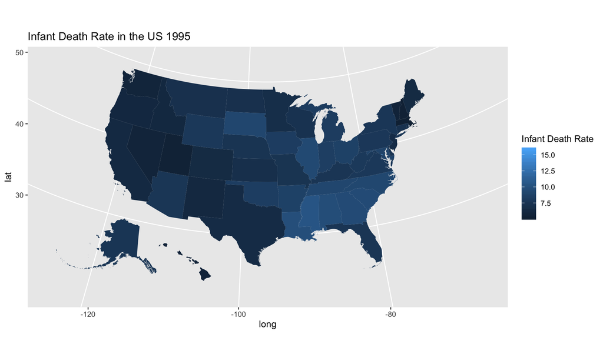

```r
All_Infant_Death_1995_By_State <- Wonder_Files_df[[1]]
All_Infant_Death_1995_By_State <- rename(All_Infant_Death_1995_By_State, state_name = State)
All_Infant_Death_1995_By_State <- rename(All_Infant_Death_1995_By_State, death_rate = "Death.Rate")

state_data_infant_death_1995 <- left_join(All_Infant_Death_1995_By_State, states,
                                          by = "state_name")
state_data_infant_death_1995 %>%
  ggplot(aes(long, lat, group = group, fill = death_rate)) +
  ggtitle("Infant Death Rate in the US 1995") +
  geom_polygon(color = NA) +
  coord_map(projection = "albers", lat0 = 39, lat1 = 45) +
  labs(fill = "Infant Death Rate")
```

#### 2007

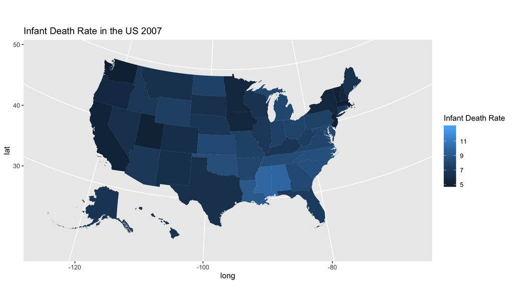

```r
All_Infant_Death_2007_By_State <- Wonder_Files_df[[13]]
All_Infant_Death_2007_By_State <- rename(All_Infant_Death_2007_By_State, state_name = State)
All_Infant_Death_2007_By_State <- rename(All_Infant_Death_2007_By_State, death_rate = "Death.Rate")

state_data_infant_death_2007 <- left_join(All_Infant_Death_2007_By_State, states,
                                          by = "state_name")
state_data_infant_death_2007 %>%
  ggplot(aes(long, lat, group = group, fill = death_rate)) +
  ggtitle("Infant Death Rate in the US 2007") +
  geom_polygon(color = NA) +
  coord_map(projection = "albers", lat0 = 39, lat1 = 45) +
  labs(fill = "Infant Death Rate")
```

#### 2017

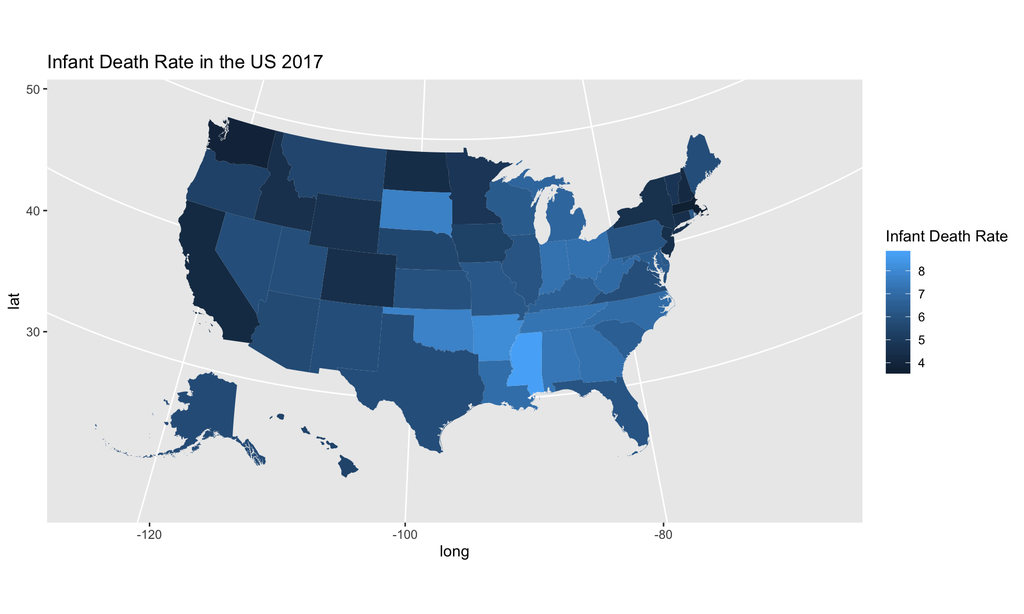

```r
All_Infant_Death_2017_By_State <- Wonder_Files_df[[23]]
All_Infant_Death_2017_By_State <- rename(All_Infant_Death_2017_By_State, state_name = State)
All_Infant_Death_2017_By_State <- rename(All_Infant_Death_2017_By_State, death_rate = "Death.Rate")

state_data_infant_death_2017 <- left_join(All_Infant_Death_2017_By_State, states,
                                          by = "state_name")
state_data_infant_death_2017 %>%
  ggplot(aes(long, lat, group = group, fill = death_rate)) +
  ggtitle("Infant Death Rate in the US 2017") +
  geom_polygon(color = NA) +
  coord_map(projection = "albers", lat0 = 39, lat1 = 45) +
  labs(fill = "Infant Death Rate")
```

### Racial Differences

A well described phenomena in the United States is the increased IMR among racial minorities. The figures below demonstrate the increased IMR for Black infants as compared to white infants. Of note 4 states have no black infant deaths reported for these 4 years.

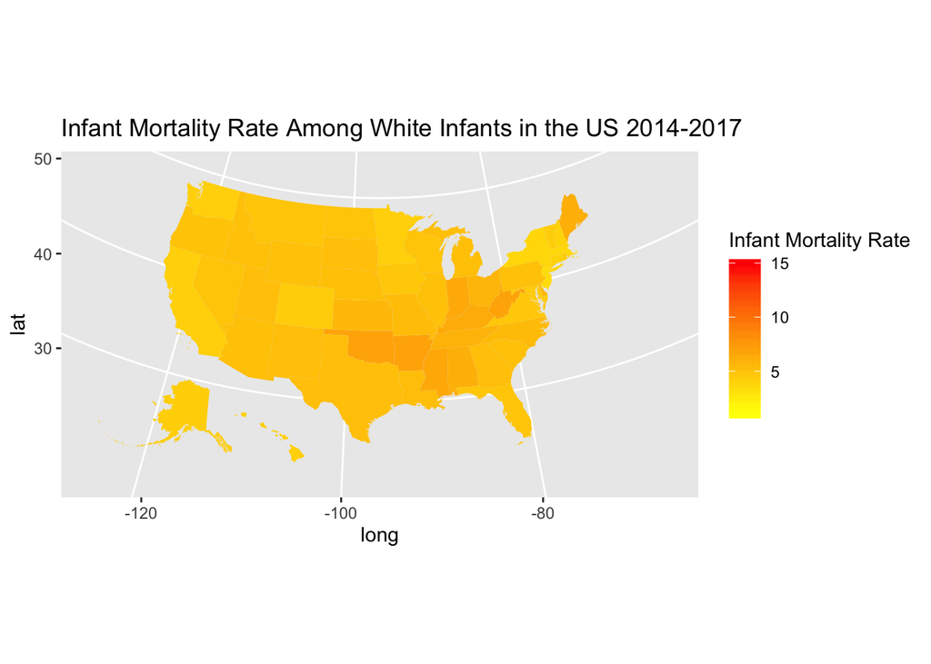

```r
white_IMR_map_14_17 %>%
  ggplot(aes(long, lat, group = group, fill = IMR)) +
  ggtitle("Infant Mortality Rate Among White Infants in the US 2014-2017") +
  geom_polygon(color = NA) +
  coord_map(projection = "albers", lat0 = 39, lat1 = 45) +
  scale_fill_gradient(limits = c(1,15), low = "yellow",high = "red") +
  labs(fill = "Infant Mortality Rate")
```

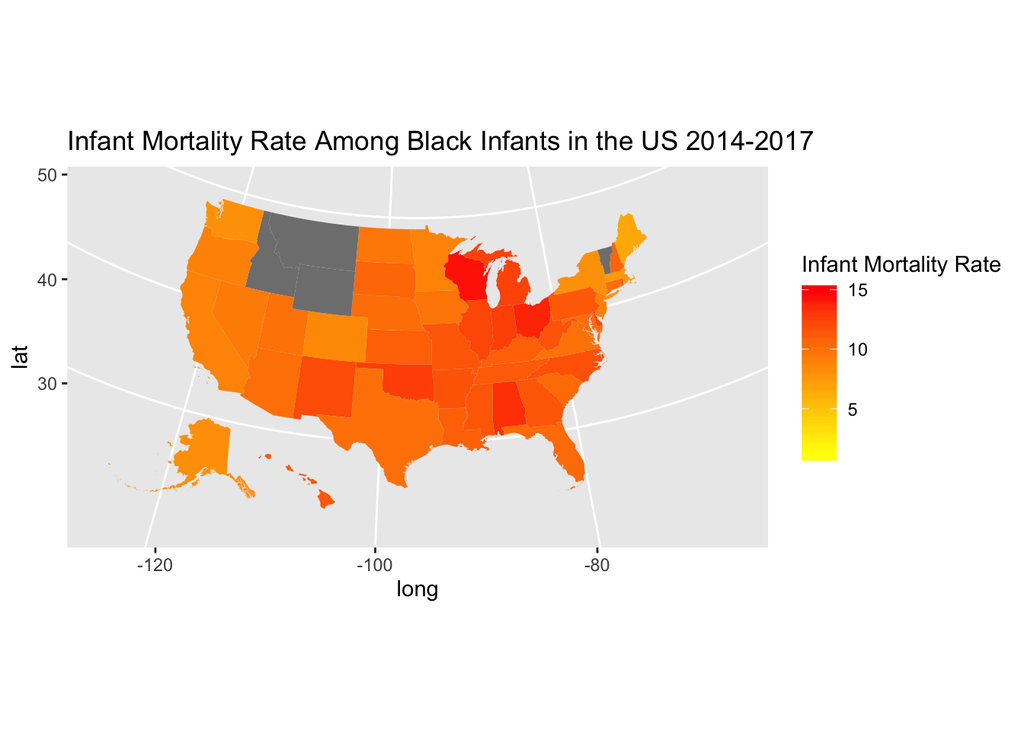

```r
black_IMR_map_14_17 %>%
  ggplot(aes(long, lat, group = group, fill = IMR)) +
  ggtitle("Infant Mortality Rate Among Black Infants in the US 2014-2017") +
  geom_polygon(color = NA) +
  coord_map(projection = "albers", lat0 = 39, lat1 = 45) +
  scale_fill_gradient(limits = c(1,15), low = "yellow",high = "red") +
  labs(fill = "Infant Mortality Rate")
```

### Improvements in IMR

As demonstrated above IMR in the US has improved significantly over the last 20 years. A significant portion of that improvement has likely come as a result of improvements in survival for infants born less than 1,500 g and more specifically less than 1,000g. Presented below is a demonstration of that for all infants born from 1995 to 2017. Data is broken down into 4 groupings representing different birth certificate epochs. The grouping for each plot are. One-way anova across the 4 time periods is also perfomed for both VLBW and ELBW infants.

- 1995-1998
- 1999-2002
- 2003-2006
- 2007-2017

#### Infants 1,000 to 1,499g

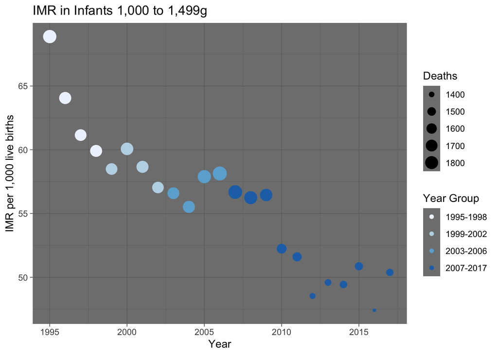

```r
aa <- ggplot(All_VLBW_IMR, aes(x=Year.of.Death, y=Death.Rate))
bb <- aa +geom_point(aes(colour = Year.Group, size=Deaths)) +
      scale_color_brewer(palette="Blues") +
      ggtitle("IMR in Infants 1,000 to 1,499g") +
      xlab("Year") +
      ylab("IMR per 1,000 live births") +
      labs(Size="Number of Deaths", colour="Year Group") +
      theme_dark()
bb
```

```r
VLBW_anova <-  aov(Death.Rate ~ Year.Group, data = All_VLBW_IMR)
tidy_VLBW_anova <- tidy(VLBW_anova)
```

#### Infants 500-999g

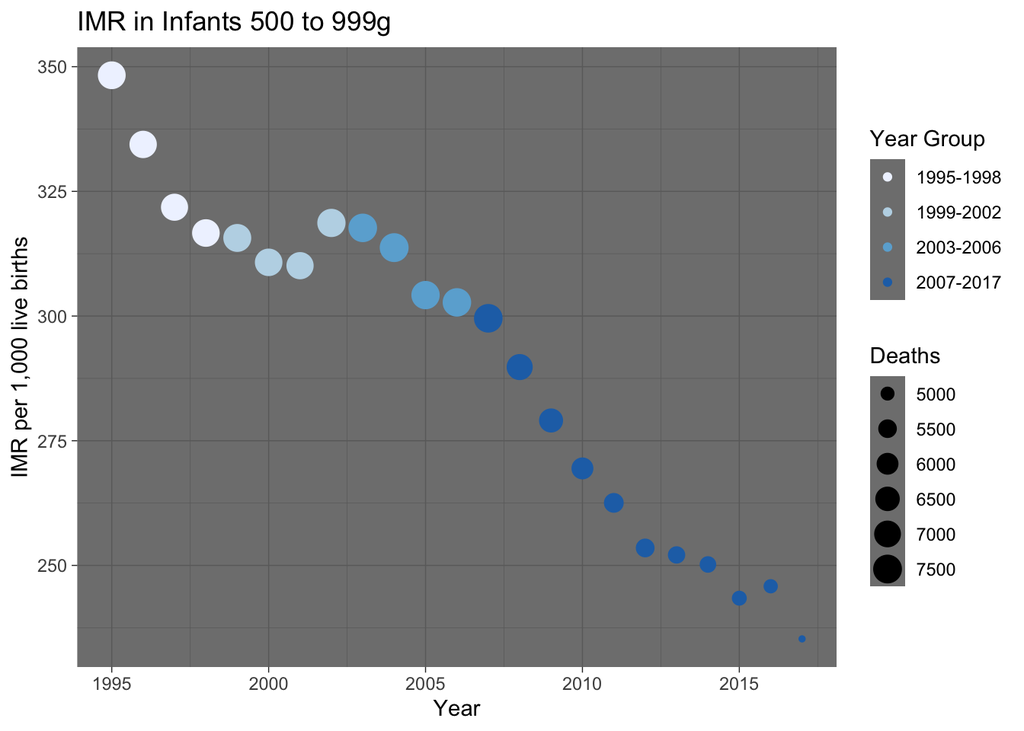

```r
cc <- ggplot(All_ELBW_IMR, aes(x=Year.of.Death, y=Death.Rate))
dd <- cc +geom_point(aes(colour = Year.Group, size=Deaths)) +
      scale_color_brewer(palette="Blues") +
      ggtitle("IMR in Infants 500 to 999g") +
      xlab("Year") +
      ylab("IMR per 1,000 live births") +
      labs(Size="Number of Deaths", colour="Year Group") +
      theme_dark()
dd
```

```r
ELBW_anova <-  aov(Death.Rate ~ Year.Group, data = All_ELBW_IMR)
tidy_ELBW_anova <- tidy(ELBW_anova)
```

IMR rates for infants in both birth weight cohorts have significantly improved over the last 20 years. One-way anova for both cohorts demonstrates significant changes over time with both models resulting in p values of less than 0.001.

##### VLBW Anova Model

```r
kable((tidy_VLBW_anova))
```

| term | df | sumsq | meansq | statistic | p.value |
| --- | --- | --- | --- | --- | --- |
| Year.Group | 3 | 452.7231 | 150.907700 | 17.32941 | 1.15e-05 |
| Residuals | 19 | 165.4555 | 8.708183 | NA | NA |

##### ELBW Anova Model

```r
kable((tidy_ELBW_anova))
```

| term | df | sumsq | meansq | statistic | p.value |
| --- | --- | --- | --- | --- | --- |
| Year.Group | 3 | 18963.257 | 6321.0858 | 24.18627 | 1.1e-06 |
| Residuals | 19 | 4965.653 | 261.3502 | NA | NA |

### Timing Prior to Death in Infancy

While the above improvements are noteworthy and described in a host of publications for the whole US birth cohort, specific interogations in these populations are still lacking. Therapies interventions being applied to these groups is likely changing the nature and timing of death among infants that continue to die during infancy in the US.

#### VLBW Infants

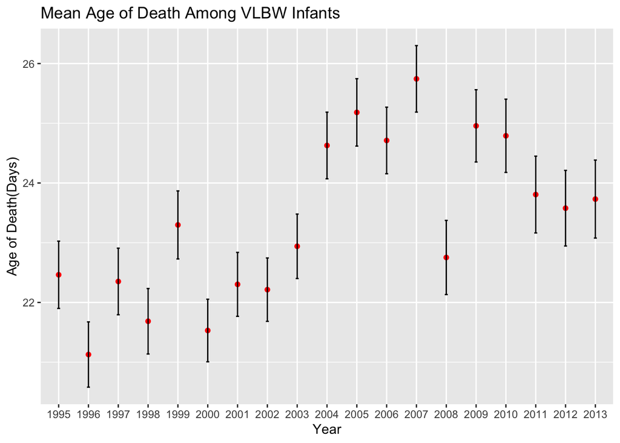

```r
gg <- ggplot(data=VLBW_rbind_ad_summ, aes(x=Year, y=mean_aged))
hh <- gg + geom_point(color="red") +
        geom_errorbar(aes(ymin=mean_aged-se_aged, ymax=mean_aged+se_aged), width=.1) +
        ggtitle("Mean Age of Death Among VLBW Infants") +
        ylab("Age of Death(Days)") +
        xlab("Year")
hh
```

#### Only Infants Born Between 1,000 and 1,499g

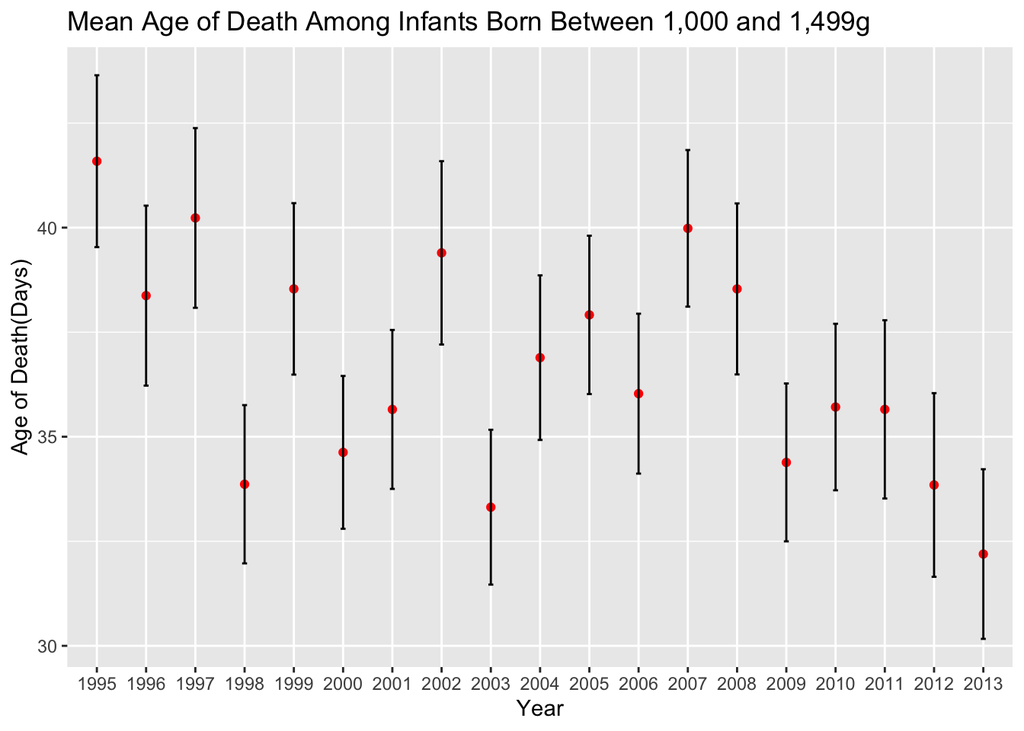

```r
ii <- ggplot(data=More_than_1000_rbind_ad_summ, aes(x=Year, y=mean_aged))
jj <- ii + geom_point(color="red") +
        geom_errorbar(aes(ymin=mean_aged-se_aged, ymax=mean_aged+se_aged), width=.1) +
        ggtitle("Mean Age of Death Among Infants Born Between 1,000 and 1,499g") +
        ylab("Age of Death(Days)") +
        xlab("Year")
jj
```

#### ELBW Infants

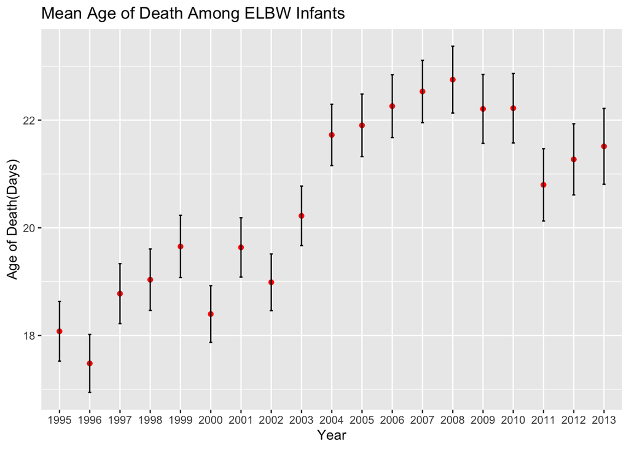

```r
ee <- ggplot(data=ELBW_rbind_ad_summ, aes(x=Year, y=mean_aged))
ff <- ee + geom_point(color="red")+
        geom_errorbar(aes(ymin=mean_aged-se_aged, ymax=mean_aged+se_aged), width=.1) +
        ggtitle("Mean Age of Death Among ELBW Infants") +
        ylab("Age of Death(Days)") +
        xlab("Year")
ff
```

Since the entire ELBW cohort is contained inside the VLBW cohort it becomes necessary to separate out those infants born 1,000 to 1,499g to avoid the problem of the ELBW cohort and their outcomes dominationg the entire VLBW cohort. When that separation is made it begins to tell the story of 2 different populations. For those infants in the VLBW cohort born greater than 1,000g it seems as if the timing of mortality has been slowly declining over time. While for those infants born under 1,000g the opposite has been happening. This may be because, while there is still early death in the greater than 1,000g group more infants are surviving overall as evidenced by the signficant drop in mortality rate an so there is simply less late death. This is likely a result of improved care practices in the neonatal care space that have benefited this group the most. For the group born less than 1,000g it may be that those same therapies have been responsible for more modest reductions in mortality and are extending the time to mortality concurrently.

#### Distribution of Times Before Death

Below is a visualization of the distribution of time before death for both VLBW and ELBW birth cohorts. It is understood in neonatal medicine that a large portion of mortality happens early in the life of babies born less than 1,500g. This early death is largely felt to be the result of the extreme physiologic immaturity present at birth. What is clear from the below histograms is that the times are clearly non-normally distributed and the majority of death is indeed within the first week of life.

#### Distribution of Time to Death for the Entire VLBW Cohort

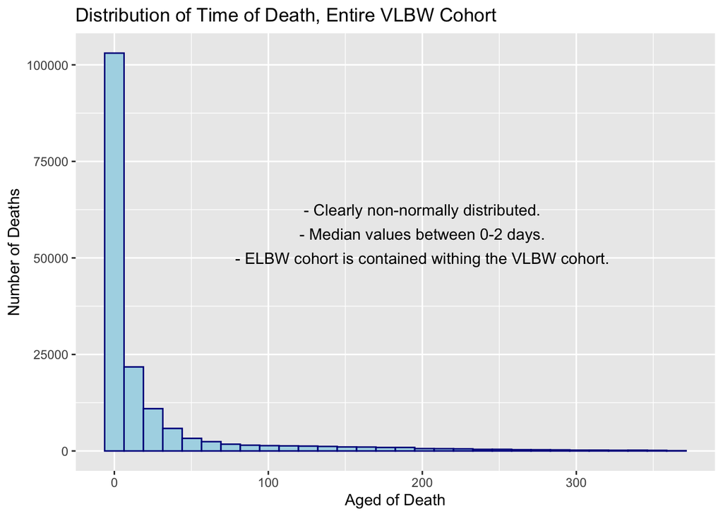

```r
ggplot(data=VLBW_rbind_ad, aes(x=aged)) +
  geom_histogram(color="darkblue", fill="lightblue") +
  xlab("Aged of Death") +
  ylab("Number of Deaths") +
  ggtitle("Distribution of Time of Death, Entire VLBW Cohort") +
  annotate("text", x = 200, y = 62500, label = "- Clearly non-normally distributed.") +
  annotate("text", x = 200, y = 56250, label = "- Median values between 0-2 days.") +
  annotate("text", x = 200, y = 50000, label = "- ELBW cohort is contained withing the VLBW cohort.")
```

##### Distribution of Time to Death for the Entire ELBW Cohort

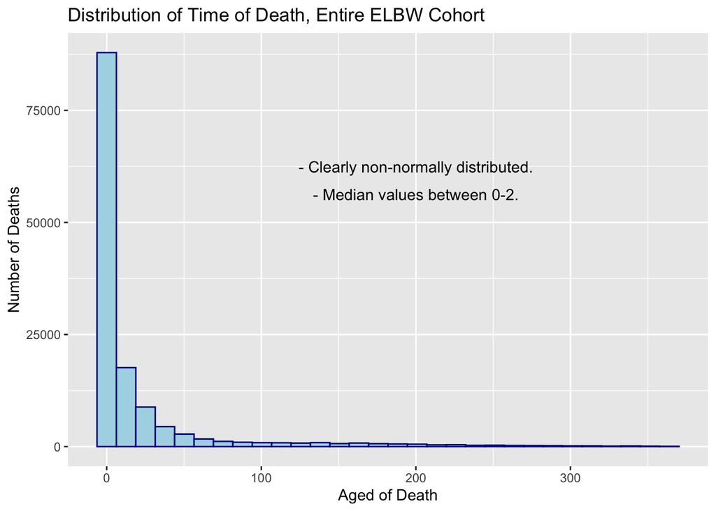

```r
ggplot(data=ELBW_rbind_ad, aes(x=aged)) + geom_histogram(color="darkblue", fill="lightblue") +xlab("Aged of Death") + ylab("Number of Deaths") +
  ggtitle("Distribution of Time of Death, Entire ELBW Cohort") + annotate("text", x = 200, y = 62500, label = "- Clearly non-normally distributed.") + annotate("text", x = 200, y = 56250, label = "- Median values between 0-2.")
```

#### Evaluating Only Those Infants Surviving Beyond 7d

Because of the amount of early mortality in these cohorts that felt to be currently non-preventable it is of interest to describe the timing of mortality for those infants that survive this first week. This is a crucial period of time for preterm infants and represents a robust enough cohort to survive at least this long.

#### Timing Prior to Death for VLBW Infants Survivng More Than 7d

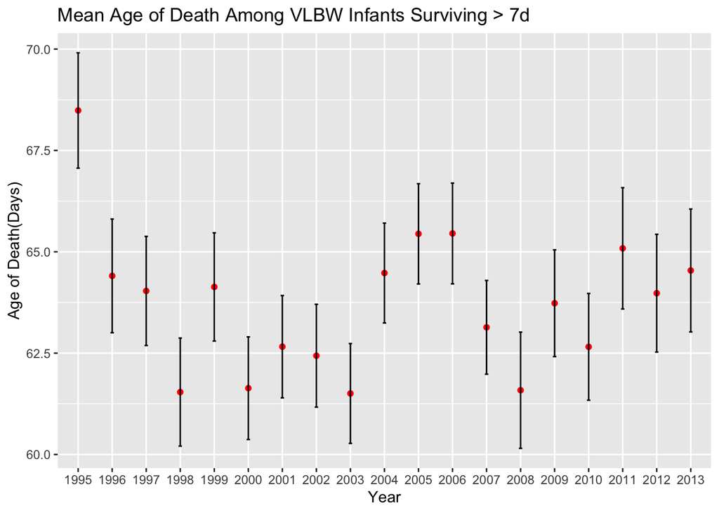

#### Timing Prior to Death for ELBW Infants Survivng More Than 7d

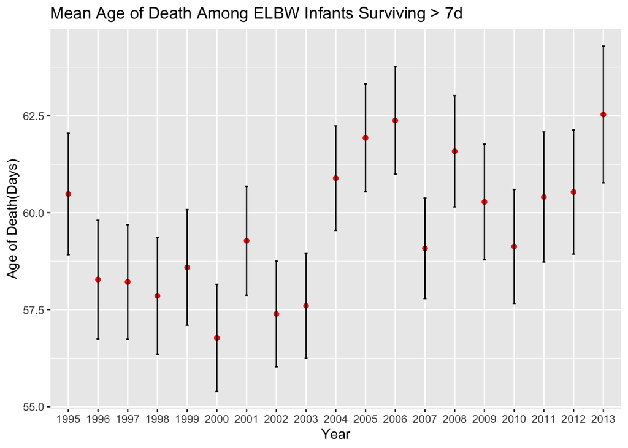

From the above visualizations it is apparent that there is a rising trend in the number of days before death among ELBW infants, **p-value < 0.001**. That same trend does not appears to be present when you expand the cohort to include the entire VLBW group.

```r
kable(tidy(ELBW_surv_8d_kw_test))
```

| statistic | p.value | parameter | method |
| --- | --- | --- | --- |
| 65.62666 | 2e-07 | 18 | Kruskal-Wallis rank sum test |

### Kaplan Meier Curves and Cox Proportional Hazard Model.

Important findings include: - The aforementioned early mortality findings. - From 1995 through 2007 the expected result was seen with the curve moving up and to the right indicating a higher percentage of infants still living at any time point. However, by 2013 the curve shifted back to be similar to the 1995 values. - Sex had no impact time to mortality surprisingly as males infants have worse outcomes routinely. - Race did impact time to mortality significantly with african american infants living longer before their death in the entire cohort.

#### Kaplan Meier Analysis 1995, 2007 and 2013 - Basic Survival Plot

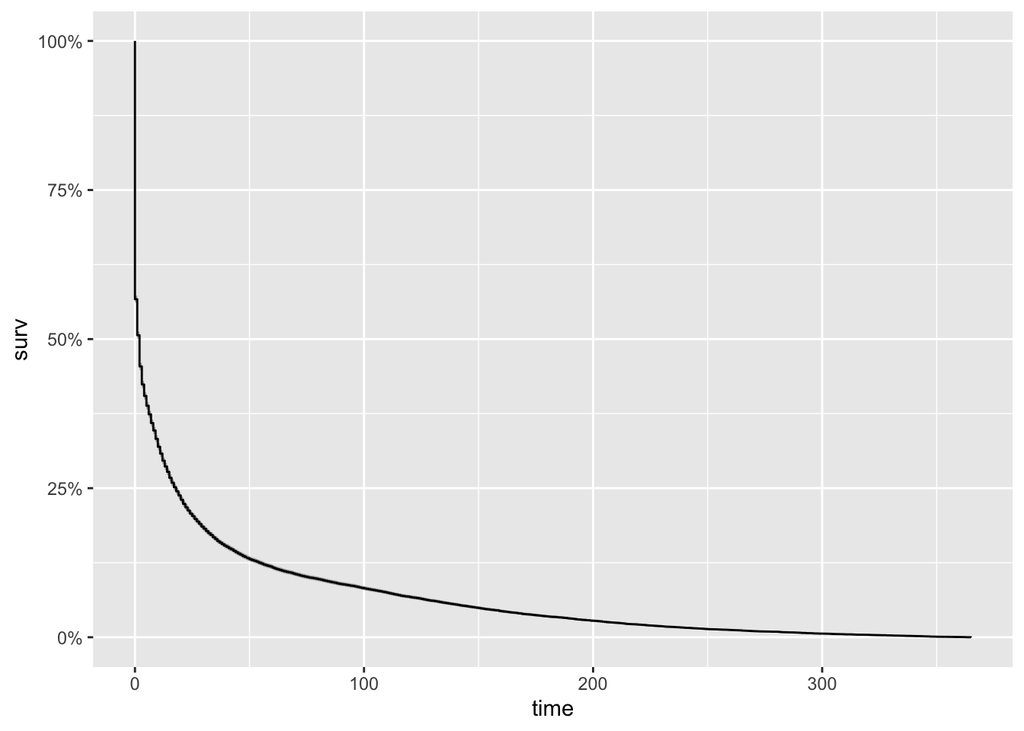

```r
km_infant_death <- with(km_infant_deaths_VLBW, Surv(aged, status))
km_infant_death_fit <- survfit(Surv(aged, status) ~ 1, data=km_infant_deaths_VLBW)
#summary(km_infant_death_fit, times = c(0,7,14,28,42,56,70,84,98,112,140,168,196,224,365))
#plot(km_infant_death_fit, xlab="Days", main = 'Kaplan Meier Curve for Entire Cohort')
autoplot(km_infant_death_fit)
```

#### Kaplan Meier Analysis 1995, 2007 and 2013 - Impact of Year

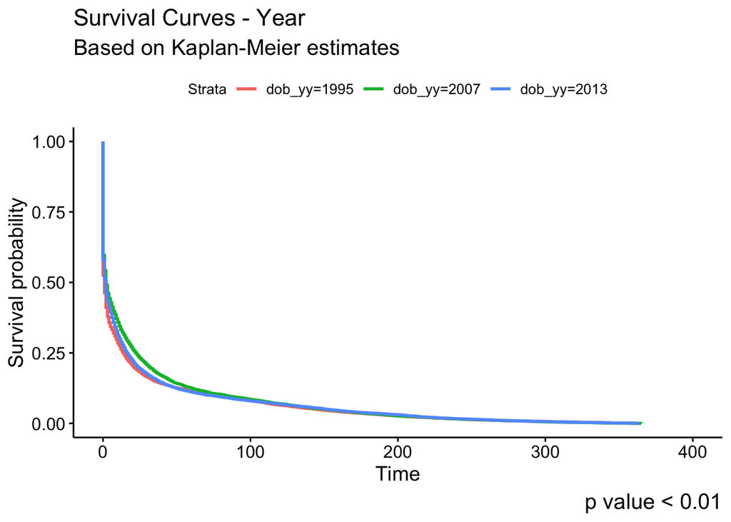

```r
km_infant_death_year_fit <- survfit(Surv(aged, status) ~ dob_yy, data=km_infant_deaths_VLBW)
#autoplot(km_infant_death_year_fit)
surv_plot_year <- ggsurvplot(km_infant_death_year_fit, data = km_infant_deaths_VLBW)
surv_plot_year$plot <- surv_plot_year$plot + labs(
  title    = "Survival Curves - Year",
  subtitle = "Based on Kaplan-Meier estimates",
  caption  = "p value < 0.01"
  )
surv_plot_year
```